# Coupon SERP Landscape Analysis

This report analyzes the SERP landscape for coupon-intent queries across five markets: **DE, ES, FR, IT, and NL**. These searches reflect strong transactional intent, where users actively look for promo codes, discounts, and special offers.

The goal of this analysis is to understand how coupon-intent SERPs differ across markets, identify the domains and SERP features that dominate these searches, and assess the organic and AI Overview visibility of Cybernews (`cybernews.com`). The analysis also looks for areas where stronger coupon coverage or product-specific content could create additional visibility opportunities.

### Datasets

The analysis is based on two complementary datasets:

- **Quantitative dataset** – keyword-level SERP feature presence (organic, AI Overviews, Top Stories, and other modules)
- **Qualitative dataset** – individual SERP items including domains, rankings, citations, and positions

The **number of tracked queries differs by locale**, and both **absolute counts and normalized metrics** are used where appropriate to ensure fair cross-market comparisons.

### Report Structure

> **Note:**  
> Full domain-level competitor lists for AI Overviews, and organic results (by market) are provided as CSV files in the repository for reference.

## SERP Feature Distribution

To establish the overall search landscape, I begin by examining **SERP feature prevalence** across all five markets.

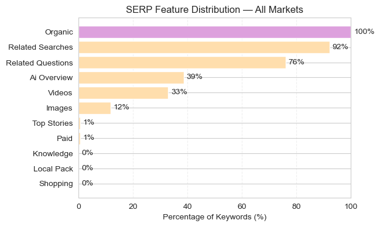

Next, I break down SERP feature prevalence at the **individual market level** to highlight differences in how coupon results pages are structured across locales.

This view helps identify where features like AI Overviews, Top Stories, or other SERP elements are more prominent and where organic visibility may face stronger competition.

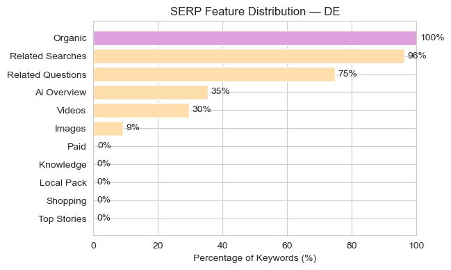

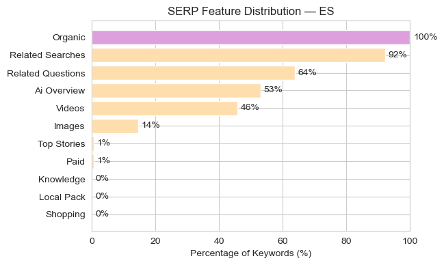

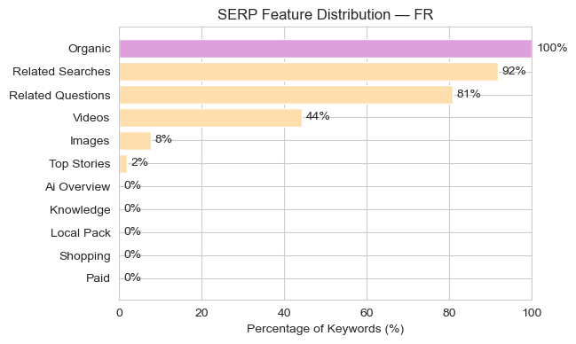

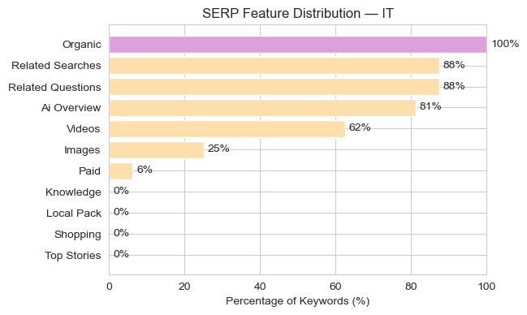

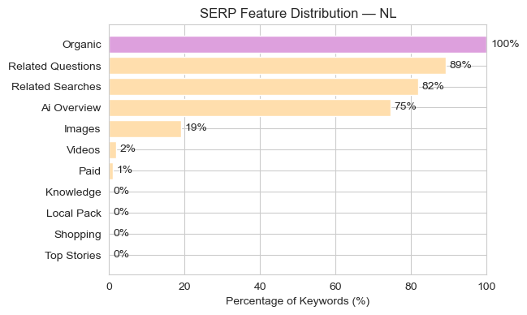

Across the analyzed markets, organic results remain consistently present, while Related Searches and Related Questions are also prominent features of coupon SERPs. Beyond these core elements, SERP composition varies more noticeably by locale, particularly for AI Overviews, video results, and the occasional Top Stories module.

Because AI Overviews and Top Stories introduce distinct visibility and competitive surfaces beyond traditional organic rankings, I examine both features in more detail below.

### Top Stories Prevalence

While Top Stories are generally uncommon for coupon and discount-focused queries, a small number of keywords still trigger them across certain markets.

To better understand where these appear and whether they represent meaningful competitive surfaces, I briefly examine their prevalence by locale and review the specific queries that activated this feature.

|  | keyword | locale | top_stories_count |
| --- | --- | --- | --- |
| 438 | oferta black friday | ES | 2 |
| 470 | offres bitdefender | FR | 4 |
| 590 | hostinger coupons | FR | 4 |
| 595 | coupon hostinger | FR | 4 |

| rank | domain | appearances |
| --- | --- | --- |
| 1 | fr.wikipedia.org | 3 |
| 2 | www.idealo.es | 2 |
| 3 | fr.igraal.com | 2 |
| 4 | businessbacon.fr | 2 |
| 5 | www.websiteplanet.com | 2 |
| 6 | www.bitdefender.com | 1 |
| 7 | fr.trustpilot.com | 1 |
| 8 | www.journaldugeek.com | 1 |

Top Stories appear only sporadically within the coupon dataset and are primarily concentrated in the FR locale for brand-specific queries such as *Hostinger* and *Bitdefender*. These results are not driven by timely news or regulatory events.

Instead, the module surfaces informational and reputation-focused content:

Hostinger results included:

- Wikipedia company overview pages (brand information)
- iGraal cashback/review listings
- Business Bacon and Website Planet affiliate-style reviews and comparisons

Bitdefender results included:

- Wikipedia brand page
- Official Bitdefender product pages
- Trustpilot reputation listings
- Journal du Geek editorial product tests

These pages focus on brand information, reviews, product evaluation, and credibility rather than discounts themselves. In this dataset, Top Stories therefore appear to function more as a **brand-context and trust surface** than as direct competition for coupon-focused pages.

> **Note:** A single ES instance was triggered by a seasonal **Black Friday** keyword and reflects temporary shopping coverage rather than typical coupon SERP behavior. I treat this instance as an outlier.

### AI Overview (AIO) Prevalence

The chart below shows the percentage of keywords that trigger an AI Overview in each locale.

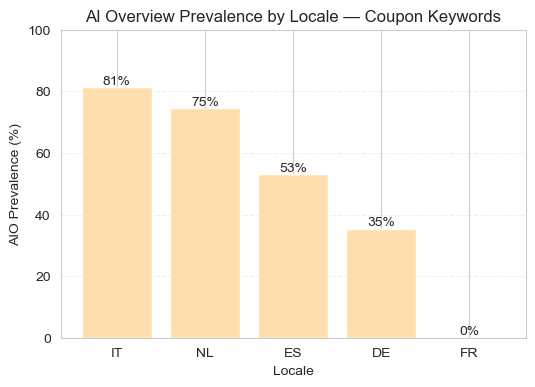

AIO prevalence is high across most analyzed markets, particularly in IT (81%) and NL (75%), where AI Overviews appear for the majority of coupon queries.

This indicates that AI Overview visibility forms a meaningful part of the search landscape for coupon-intent queries in these markets, making source citations relevant alongside traditional organic rankings.

> **Note:** FR shows 0% prevalence; however, this reflects an API limitation where AI Overview data is not currently returned for this locale rather than true absence on Google.

The following sections examine market-level differences in SERP structure, dominant domains, and Cybernews' organic and AI Overview visibility.

## Top Domains in Germany (DE)

To establish the competitive landscape in Germany, I first examine the domains with the highest overall SERP appearance frequency across the coupon keyword set. Domain dominance is defined as the number of times a domain appears across visibility-driving SERP elements, including organic results, Top Stories, and AI Overview sources.

|  | domain | appearances |
| --- | --- | --- |
| 0 | www.mydealz.de | 205 |
| 1 | www.sparwelt.de | 202 |
| 2 | www.groupon.de | 165 |
| 3 | nordvpn.com | 157 |
| 4 | cybernews.com | 150 |
| 5 | www.gutscheinsammler.de | 128 |
| 6 | www.rabattcode.de | 125 |
| 7 | www.coupons.de | 98 |
| 8 | www.reddit.com | 90 |
| 9 | www.urlaubstracker.de | 78 |
| 10 | www.gutegutscheine.de | 65 |
| 11 | surfshark.com | 64 |
| 12 | www.einfach-sparsam.de | 60 |
| 13 | protonvpn.com | 59 |
| 14 | www.youtube.com | 56 |
| 15 | www.iamstudent.de | 54 |
| 16 | www.businessinsider.de | 48 |
| 17 | www.studentbeans.com | 46 |
| 18 | proton.me | 44 |
| 19 | translate.google.com | 44 |

The German coupon SERP landscape is led primarily by **deal aggregators and voucher platforms**, although brand-owned domains also hold substantial visibility.

### Organic Position #1 in Germany

Here you can also see the **organic position #1 visibility** in the German market. Here, position #1 refers to the first organic result on the SERP, excluding paid placements and SERP features such as Top Stories or AI Overviews.

|  | domain | position_1_count |
| --- | --- | --- |
| 0 | www.mydealz.de | 125 |
| 1 | www.sparwelt.de | 12 |
| 2 | www.hosttest.de | 10 |
| 3 | nordvpn.com | 9 |
| 4 | www.gutegutscheine.de | 9 |
| 5 | surfshark.com | 8 |
| 6 | protonvpn.com | 8 |
| 7 | www.gutscheinsammler.de | 8 |
| 8 | de.wix.com | 7 |
| 9 | de.hostadvice.com | 7 |

To isolate **organic search visibility**, I next examine the domains with the highest number of appearances specifically within organic results.

|  | domain | appearances |
| --- | --- | --- |
| 0 | www.mydealz.de | 203 |
| 1 | www.sparwelt.de | 167 |
| 2 | www.groupon.de | 137 |
| 3 | www.gutscheinsammler.de | 128 |
| 4 | www.rabattcode.de | 117 |
| 5 | nordvpn.com | 109 |
| 6 | cybernews.com | 102 |
| 7 | www.coupons.de | 98 |
| 8 | www.reddit.com | 83 |
| 9 | www.gutegutscheine.de | 63 |

Taken together, these views highlight a distinction between **overall organic visibility and top-position ownership**. Several coupon aggregators and brand domains appear frequently across organic results, but `mydealz.de` stands out with a disproportionately high number of position #1 rankings.

The broader organic landscape is therefore relatively distributed, while the very top position is much more concentrated. Cybernews also maintains substantial organic visibility overall, so the next section examines where those appearances are distributed across ranking positions.

### Organic Performance — Cybernews (Germany)

Next, I examine the organic ranking distribution for **Cybernews (`cybernews.com/de`)** to understand where its visibility is concentrated across the first page of results.

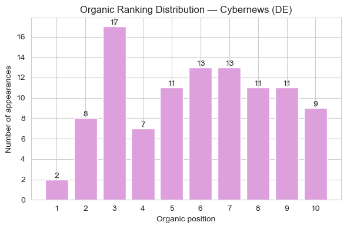

Cybernews maintains visibility across the full first page, but relatively few appearances reach the very top organic position. The distribution is stronger across positions 3–9, suggesting that overall visibility is established, while further gains would depend on moving existing rankings higher within the SERP.

To understand where Cybernews achieves its strongest organic visibility, I next examine the queries ranking in positions **1–3** and the products associated with them.

|  | keyword | position |
| --- | --- | --- |
| 0 | oura gutscheincode | 1 |
| 1 | protonpass coupon | 1 |
| 2 | 1password rabatt | 2 |
| 3 | nord incogni coupon | 2 |
| 4 | proton unlimited gutscheincode | 2 |
| 5 | proton vpn coupon codes | 2 |
| 6 | proton vpn coupons | 2 |
| 7 | proton vpn gutschein | 2 |
| 8 | protonvpn coupons | 2 |
| 9 | roboform coupon | 2 |
| 10 | 1password coupon | 3 |
| 11 | 1password coupon code | 3 |
| 12 | 1password coupon codes | 3 |
| 13 | 1password gutschein | 3 |
| 14 | 1password gutschein code | 3 |
| 15 | 1password rabattcode | 3 |
| 16 | bluehost coupons | 3 |
| 17 | gutscheincode proton | 3 |
| 18 | proton gutschein | 3 |
| 19 | proton vpn coupon | 3 |
| 20 | proton vpn coupon code | 3 |
| 21 | proton vpn rabattcode | 3 |
| 22 | protonvpn coupon | 3 |
| 23 | protonvpn gutschein | 3 |
| 24 | protonvpn gutscheincode | 3 |
| 25 | rabattcode hume health | 3 |
| 26 | surfshark coupon | 3 |

Across 27 keywords where `cybernews.com/de` ranks within the top 3 organic results, Proton-related queries account for just over half of these rankings (~52%), followed by 1Password (around 26%). This shows that Cybernews achieves its strongest top-position visibility in Germany for Proton and 1Password-related coupon queries, while other product groups appear less frequently in the top 3.

### AI Overviews in Germany

This section analyzes **AI Overview (AIO) sources** in the German coupon SERPs. Domain dominance is defined by frequency of appearance as a cited source within AI Overviews.

I first review the most frequently cited domains overall and then examine how often **cybernews.com/de** appears and at which citation positions.

|  | domain | aio_citations |
| --- | --- | --- |
| 0 | www.youtube.com | 54 |
| 1 | nordvpn.com | 48 |
| 2 | cybernews.com | 48 |
| 3 | translate.google.com | 44 |
| 4 | www.sparwelt.de | 35 |
| 5 | www.groupon.de | 28 |
| 6 | protonvpn.com | 22 |
| 7 | www.handelsblatt.com | 21 |
| 8 | www.idealo.de | 19 |
| 9 | de.wizcase.com | 18 |

The German AIO source landscape is more mixed than the organic results, combining video platforms, first-party brand domains, coupon sites, and editorial publishers. YouTube is the most frequently cited source, while NordVPN and Cybernews are tied as the next most visible domains with 48 citations each.

Cybernews therefore holds a strong overall presence within AI Overviews in the German coupon dataset, making the position of those citations particularly relevant.

### AIO Performance — Cybernews (Germany)

To assess the strength of this visibility, I next examine where Cybernews appears within the AIO citation order.

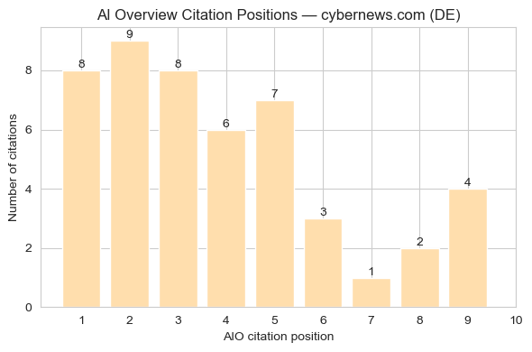

Cybernews' AIO visibility is concentrated toward the higher citation positions. Just over half of its citations appear within positions 1–3 (25 of 48), while roughly four in five appear within the top five citation positions (38 of 48).

Below are the keywords where cybernews.com appears within the top 3 citation positions inside AI Overviews in the German market:

|  | keyword | position |
| --- | --- | --- |
| 0 | 1password coupon code | 1 |
| 1 | 1password coupon codes | 1 |
| 2 | 1password rabattcode | 1 |
| 3 | bitdefender coupon 2026 | 1 |
| 4 | bitdefender coupon code 2026 | 1 |
| 5 | proton vpn coupon codes | 1 |
| 6 | surfshark vpn angebote | 1 |
| 7 | vpn-angebote vergleich | 1 |
| 8 | 1password coupon code | 2 |
| 9 | 1password coupon codes | 2 |
| 10 | bitdefender antivirus coupon | 2 |
| 11 | nord vpn gutscheincode | 2 |
| 12 | nordvpn gutscheincode august 2026 deutschland | 2 |
| 13 | nordvpn gutscheincode deutschland | 2 |
| 14 | proton coupons | 2 |
| 15 | surfshark studentenrabatt | 2 |
| 16 | vpn gutscheincode | 2 |
| 17 | nord rabattcode | 3 |
| 18 | nord+vpn+rabattgutscheine | 3 |
| 19 | nordvpn rabattcode aktuell | 3 |
| 20 | nordvpn rabattcode deutschland | 3 |
| 21 | proton coupon | 3 |
| 22 | proton unlimited gutscheincode | 3 |
| 23 | rabattcode hume health | 3 |
| 24 | rabattcodes surfshark | 3 |

Across 25 top-three citation appearances, Cybernews' strongest AIO visibility is spread across several major product groups. NordVPN accounts for around 28%, followed by 1Password at around 20% and Proton at approximately 16%. Bitdefender and Surfshark each contribute around 12%, showing a broader product distribution than the top organic rankings.

### Germany — Key Findings

Overall, Germany shows a clear difference between traditional organic and AI-driven visibility. The highest organic position is heavily concentrated around a small number of competitors, particularly `mydealz.de`, while Cybernews has a comparatively stronger presence within AI Overviews than at the very top of the organic results.

Cybernews' strongest organic rankings are concentrated around Proton and 1Password-related queries, whereas its top AIO citations are distributed across a broader range of products. This suggests that, within the German coupon dataset, AI Overviews currently provide a particularly strong visibility surface for Cybernews alongside its established organic presence.

## Remaining markets – summary approach

The remaining markets — **ES, IT, NL, and FR** — are analyzed in a condensed format, focusing on the main competitive patterns and Cybernews' organic and AI Overview visibility.

Complete domain-level competitor lists for organic results and AI Overview sources are included as separate CSV files in the repository for detailed reference.

## ES (Spain)

I first examine the domains with the strongest organic visibility in Spain, looking at both **position #1 ownership** and **overall organic appearances**.

|  | domain | position_1_count |
| --- | --- | --- |
| 0 | www.chollometro.com | 63 |
| 1 | surfshark.com | 11 |
| 2 | www.websiteplanet.com | 9 |
| 3 | www.radarcupon.es | 7 |
| 4 | nordvpn.com | 6 |
| 5 | www.opiniones.hosting | 5 |
| 6 | protonvpn.com | 5 |
| 7 | www.cupones.es | 4 |
| 8 | es.wix.com | 4 |
| 9 | www.escuderia.com | 4 |

|  | domain | appearances |
| --- | --- | --- |
| 0 | www.chollometro.com | 124 |
| 1 | www.radarcupon.es | 85 |
| 2 | www.cupones.es | 72 |
| 3 | www.websiteplanet.com | 52 |
| 4 | www.cuponation.es | 52 |
| 5 | www.promodescuentos.com | 52 |
| 6 | es.igraal.com | 50 |
| 7 | es.hostadvice.com | 50 |
| 8 | www.opiniones.hosting | 36 |
| 9 | nordvpn.com | 35 |

The Spanish coupon SERP is strongly led by dedicated deal and coupon platforms. `chollometro.com` stands out in particular, leading both overall organic appearances and position #1 rankings by a substantial margin.

Other coupon-focused domains such as `radarcupon.es`, `cupones.es`, and `cuponation.es` also maintain strong overall visibility, while first-party brands such as Surfshark and NordVPN appear among the domains reaching the top organic position.

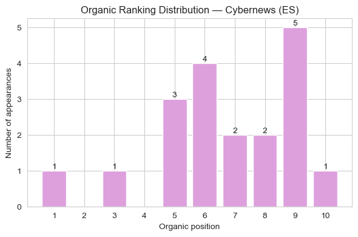

Cybernews has a smaller organic footprint in Spain than the leading coupon domains, with most of its rankings concentrated in the middle and lower portion of the first page.

Of the 19 recorded organic appearances, only two occur within positions 1–3, while the majority fall between positions 5 and 9. This indicates established first-page visibility, but relatively limited presence at the very top of the Spanish organic results.

### Spain AIO

I next take a look at the most frequently cited domains within AI Overviews for Spanish coupon queries.

|  | domain | aio_citations |
| --- | --- | --- |
| 0 | www.youtube.com | 58 |
| 1 | www.chollometro.com | 45 |
| 2 | www.promodescuentos.com | 26 |
| 3 | translate.google.com | 24 |
| 4 | www.hostinger.com | 20 |
| 5 | es.hostadvice.com | 20 |
| 6 | es.igraal.com | 18 |
| 7 | cybernews.com | 16 |
| 8 | www.megadescuentos.com | 15 |
| 9 | www.opiniones.hosting | 14 |

The Spanish AIO landscape includes a mix of video, coupon, brand-owned, and editorial or comparison sources. YouTube is the most frequently cited domain, followed by `chollometro.com` and `promodescuentos.com`.

Coupon-focused platforms therefore maintain substantial visibility within AI Overviews as well as organic results, although the AIO source mix is broader and also includes first-party and editorial domains. Cybernews appears among the ten most frequently cited sources, with 16 citation appearances.

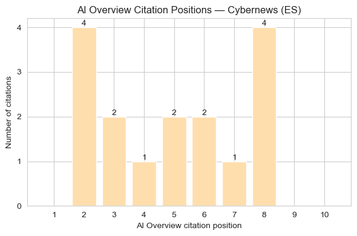

Cybernews' AIO citations are distributed across positions 2–8, with six of the 16 appearances occurring within the top three citation positions. More than half of all citations (9 of 16) appear within the top five.

The table below shows the queries where Cybernews appears as an AI Overview citation in Spain:

|  | keyword | position |
| --- | --- | --- |
| 0 | codigo promocional hostinger horizons | 2 |
| 1 | cupon descuento norton | 2 |
| 2 | mejores ofertas vpn | 2 |
| 3 | nordvpn cupon descuento 2026 | 2 |
| 4 | codigo descuento norton | 3 |
| 5 | codigo promocional norton | 3 |
| 6 | cupon de descuento norton | 4 |
| 7 | cupon descuento bitdefender | 5 |
| 8 | cupones antivirus | 5 |
| 9 | hostinger cupon descuento julio 2026 | 6 |
| 10 | nord vpn ofertas en línea | 6 |
| 11 | purevpn cupon | 7 |
| 12 | codigo descuento norton | 8 |
| 13 | codigo nordvpn | 8 |
| 14 | cupon descuento norton | 8 |
| 15 | mejores ofertas vpn | 8 |

Cybernews' AIO visibility spans several product groups, with Norton appearing particularly frequently among the cited queries. NordVPN and Hostinger also contribute multiple appearances, alongside Bitdefender, PureVPN, and broader VPN-related searches.

Overall, Cybernews shows stronger top-position visibility within AI Overviews than in the Spanish organic results. While its organic rankings are concentrated mainly in positions 5–9, its AIO citations reach the top positions more frequently, providing an additional visibility surface in a market where the highest organic positions are strongly occupied by established coupon platforms.

## IT (Italy)

|  | domain | position_1_count |
| --- | --- | --- |
| 0 | surfshark.com | 5 |
| 1 | nordvpn.com | 4 |
| 2 | esim.holafly.com | 2 |
| 3 | www.hostinger.com | 1 |
| 4 | bitdefender.codice-sconto.net | 1 |
| 5 | www.codicesconto.com | 1 |
| 6 | mcafee.codice-sconto.net | 1 |
| 7 | eset.codice-sconto.net | 1 |

|  | domain | appearances |
| --- | --- | --- |
| 0 | www.codicesconto.com | 17 |
| 1 | www.discoup.com | 10 |
| 2 | www.studentbeans.com | 9 |
| 3 | www.trustdeals.it | 8 |
| 4 | www.trovaprezzi.it | 8 |
| 5 | surfshark.com | 8 |
| 6 | it.bestshopping.com | 6 |
| 7 | www.radarcoupon.it | 6 |
| 8 | www.cuponation.it | 5 |
| 9 | support.nordvpn.com | 5 |

The Italian organic landscape is relatively distributed among coupon platforms and first-party domains. `codicesconto.com` records the highest overall organic visibility with 17 appearances, while Surfshark and NordVPN lead position #1 ownership with five and four rankings respectively.

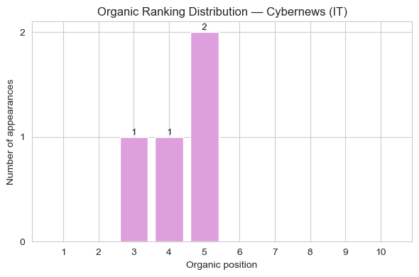

Cybernews has limited organic visibility in Italy, appearing for four tracked queries across positions 3–5. All four rankings are associated with NordVPN coupon searches.

The keywords we rank for in these positions:

|  | keyword | position |
| --- | --- | --- |
| 0 | codici sconto nordvpn | 3 |
| 1 | codici sconto nord vpn | 4 |
| 2 | codici nordvpn | 5 |
| 3 | nordvpn codici sconto | 5 |

### Italy AIO

|  | domain | aio_citations |
| --- | --- | --- |
| 0 | www.codicesconto.com | 10 |
| 1 | surfshark.com | 7 |
| 2 | www.studentbeans.com | 6 |
| 3 | www.trovaprezzi.it | 5 |
| 4 | nordvpn.com | 4 |
| 5 | www.cuponation.it | 4 |
| 6 | sconti.com | 4 |
| 7 | cybernews.com | 4 |
| 8 | www.abbonamenti.it | 3 |
| 9 | www.groupon.it | 3 |

The Italian AIO source landscape is led by `codicesconto.com`, followed by Surfshark and Student Beans. Cybernews appears four times as an AIO source, placing it among the ten most frequently cited domains in the dataset.

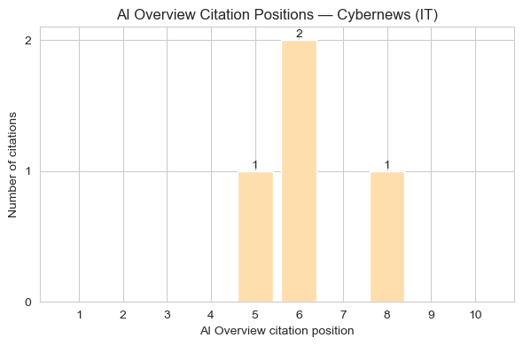

Cybernews' four AIO citation appearances occur at positions 5, 6, 6, and 8.

|  | keyword | position | count |
| --- | --- | --- | --- |
| 1 | codici sconto nordvpn | 5 | 1 |
| 0 | codici sconto nord vpn | 6 | 1 |
| 3 | nordvpn codici sconto | 6 | 1 |
| 2 | codici sconto nordvpn | 8 | 1 |

As with organic search, Cybernews' AIO visibility in Italy is entirely concentrated around NordVPN-related queries.

Overall, Cybernews has a relatively small footprint in the Italian coupon dataset, with both organic and AIO visibility concentrated exclusively around NordVPN-related searches. These lower absolute counts should be interpreted in the context of the smaller Italian keyword sample and Cybernews' smaller content footprint in this locale, both of which contribute to fewer potential SERP appearances.

## NL (Netherlands)

|  | domain | position_1_count |
| --- | --- | --- |
| 0 | www.acties.nl | 49 |
| 1 | nordvpn.com | 17 |
| 2 | surfshark.com | 5 |
| 3 | www.vpngids.nl | 4 |
| 4 | protonvpn.com | 4 |
| 5 | www.websiteplanet.com | 4 |
| 6 | nl.norton.com | 3 |
| 7 | nl.pepper.com | 3 |
| 8 | support.spotify.com | 2 |
| 9 | nl.hotdeals.com | 2 |

|  | domain | appearances |
| --- | --- | --- |
| 0 | www.acties.nl | 79 |
| 1 | licentie2go.com | 65 |
| 2 | nl.pepper.com | 64 |
| 3 | nordvpn.com | 57 |
| 4 | www.kortingscode.nl | 48 |
| 5 | cybernews.com | 40 |
| 6 | www.cashbackxl.nl | 30 |
| 7 | www.trustdeals.nl | 26 |
| 8 | www.groupon.nl | 26 |
| 9 | nl.vpnmentor.com | 25 |

The Dutch organic landscape is led by `acties.nl`, which records both the highest number of overall organic appearances and the most position #1 rankings. First-party domains such as NordVPN also hold prominent top-ranking visibility. Cybernews appears among the more visible domains overall, although its rankings are concentrated primarily outside the highest organic positions.

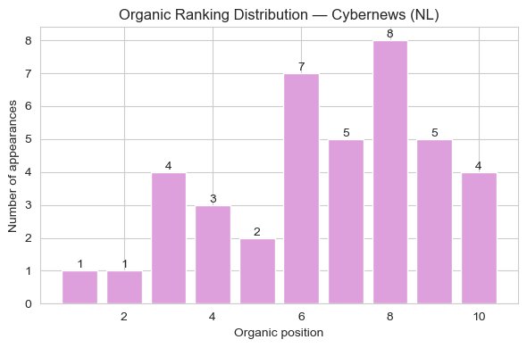

Cybernews' organic visibility is weighted toward the middle and lower part of the first page, with relatively few appearances in positions 1–3.

The table below shows the queries where Cybernews ranks within the top three organic positions:

|  | keyword | position |
| --- | --- | --- |
| 0 | 1password promo | 1 |
| 1 | bluehost promo code | 2 |
| 2 | proton code promo | 3 |
| 3 | protonvpn code promo | 3 |
| 4 | protonvpn promo code | 3 |
| 5 | wix promo code | 3 |

Cybernews' strongest organic rankings span several products, including 1Password, Bluehost, Proton, and Wix, with Proton accounting for the largest share of these top placements.

### Netherlands AIO

|  | domain | aio_citations |
| --- | --- | --- |
| 0 | nordvpn.com | 66 |
| 1 | nl.pepper.com | 39 |
| 2 | www.kortingscode.nl | 35 |
| 3 | translate.google.com | 25 |
| 4 | cybernews.com | 24 |
| 5 | www.acties.nl | 24 |
| 6 | www.reddit.com | 20 |
| 7 | support.nordvpn.com | 19 |
| 8 | licentie2go.com | 18 |
| 9 | nl.norton.com | 18 |

The Dutch AIO landscape differs from organic search, with `nordvpn.com` emerging as the most prominent cited source. Cybernews also appears among the leading AIO sources, alongside coupon platforms, community sources, and other first-party domains.

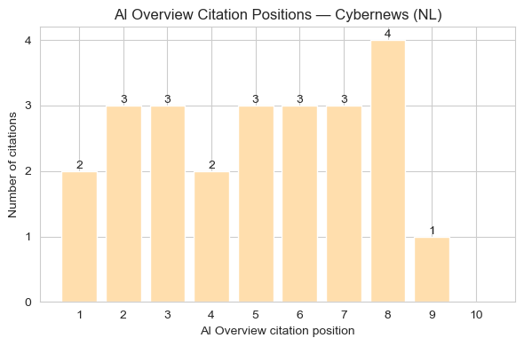

|  | keyword | position |
| --- | --- | --- |
| 0 | bluehost promo code | 1 |
| 1 | code promo surfshark | 1 |
| 2 | promo nord vpn | 2 |
| 3 | promotiecode wix | 2 |
| 4 | proton code promo | 2 |
| 5 | nord vpn promotiecodes | 3 |
| 6 | surfshark promotiecodes | 3 |
| 7 | vpn promos | 3 |

Cybernews' strongest AIO placements span a broader product mix, including Bluehost, Surfshark, NordVPN, Wix, and Proton, alongside a generic VPN promotion query.

Overall, Cybernews has meaningful visibility in the Dutch coupon dataset, but its strongest placements are more apparent within AI Overviews than in organic search. Its AIO visibility also spans a broader mix of product-related queries.

## FR (France)

|  | domain | position_1_count |
| --- | --- | --- |
| 0 | www.dealabs.com | 41 |
| 1 | www.ma-reduc.com | 14 |
| 2 | surfshark.com | 10 |
| 3 | www.hostinger.com | 7 |
| 4 | fr.wix.com | 7 |
| 5 | independant.io | 6 |
| 6 | fr.hostadvice.com | 6 |
| 7 | www.ionos.fr | 5 |
| 8 | www.reduc.fr | 5 |
| 9 | www.influenceur.promo | 5 |

|  | domain | appearances |
| --- | --- | --- |
| 0 | fr.igraal.com | 86 |
| 1 | www.dealabs.com | 78 |
| 2 | www.ma-reduc.com | 76 |
| 3 | nordvpn.com | 46 |
| 4 | www.01net.com | 44 |
| 5 | www.journaldugeek.com | 43 |
| 6 | fr.hostadvice.com | 42 |
| 7 | www.poulpeo.com | 40 |
| 8 | www.reduc.fr | 38 |
| 9 | support.nordvpn.com | 37 |

The French organic landscape is led primarily by coupon and deal platforms, with `dealabs.com`, `ma-reduc.com`, and `igraal.com` among the most prominent domains. Compared with some of the other markets, the visible competitor mix also includes several editorial and technology publishers, such as `01net.com` and `journaldugeek.com`, alongside first-party brand domains.

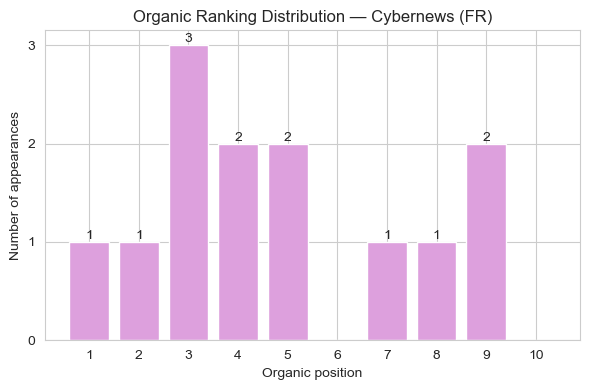

Cybernews' organic rankings are spread across most of the first page, with its strongest concentration around the upper-middle positions rather than a single dominant ranking position.

The queries in the to-3 positions are the following:

|  | keyword | position |
| --- | --- | --- |
| 0 | antivirus codes | 1 |
| 1 | nordvpn youtube codes | 2 |
| 2 | code promo 1password | 3 |
| 3 | nordvpn coupon youtube | 3 |
| 4 | nordvpn sponsor codes | 3 |

Cybernews' strongest organic rankings are concentrated mainly around NordVPN-related searches, alongside individual top placements for 1Password and a broader antivirus coupon query.

### Potential Opportunity — France

Cybernews' strongest French rankings are concentrated around NordVPN queries with more specific promotional intent, including YouTube and sponsor-code searches, while broader coupon SERPs are heavily occupied by established deal platforms.

A potential opportunity is therefore to expand around these more specific **product + promotion-type** query patterns rather than competing primarily for broad generic coupon terms (e.g. creating pages for topics like "Best NordVPN Youtuber discount codes"). Similar content could be tested for other products where Cybernews already has topical visibility, using variants such as influencer codes, sponsor codes, YouTube promotions, or other product-specific discount searches.

Because AI Overview data is unavailable for France, this opportunity is based on organic search performance only.

## Cross-market comparison of organic visibility

The visualization below compares how Cybernews ranks organically across the five analyzed markets.  
Each line represents the number of appearances at a given organic position (1–10).

It must be noted that the amount of content each locale owns has an influence on the number of appearances in SERP.

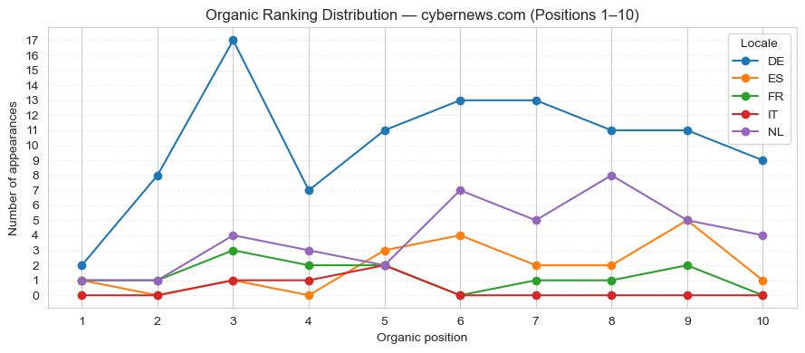

Germany shows the broadest organic footprint in the dataset, with Cybernews appearing consistently across the first page and a substantial share of rankings already sitting within positions where further upward movement is realistic.

The Netherlands also shows meaningful first-page coverage, although more of this visibility is concentrated outside the highest-ranking positions. Spain follows a similar pattern on a smaller scale, while France and Italy have much smaller organic footprints.

> **Note on comparability (absolute vs normalized):**  
> The chart above shows **absolute appearance counts**. Because the number of keywords (and overall content footprint) differs by locale, markets with larger query sets can naturally produce higher counts.  
> To enable a more comparable view across locales, the following chart shows **normalized appearances per 100 keywords**.

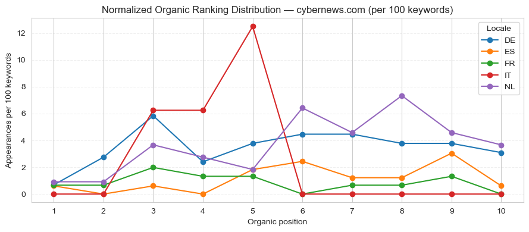

### Cross-Market Organic Opportunity

The normalized view helps separate ranking performance from differences in keyword-set size and provides a clearer picture of where Cybernews already has competitive first-page visibility.

Across the markets, the most immediate opportunity lies in queries where Cybernews already ranks on the first page but has not yet reached the highest positions. These rankings already demonstrate relevance, making them strong candidates for further optimization — particularly where the associated products are commercially important.

Germany, the Netherlands, and Spain show the clearest examples of this pattern, with a meaningful share of Cybernews rankings sitting below the top positions. In these cases, the priority would be to assess existing pages for potential improvements such as stronger alignment with coupon intent, content refreshes, internal linking, or gaps relative to higher-ranking competitors.

Markets with a smaller visibility footprint require a different interpretation. Some gaps may reflect weaker rankings for existing content, while others may simply indicate that relevant coupon coverage does not yet exist. Distinguishing between **ranking gaps** and **content gaps** therefore helps determine whether the better opportunity is to optimize an existing page or expand coverage into new query areas.

## NordVPN Coupon Queries

After reviewing the broader coupon landscape, I next isolate **NordVPN-related queries** to examine how competition and Cybernews' visibility change within a single commercially important product segment.

The analysis covers **DE, ES, FR, IT, and NL** and compares:

- **Organic dominance** using a *position-weighted visibility score* (higher rankings contribute more weight)
- **AI Overview (AIO) source dominance** by citation frequency
- **Cybernews’ organic ranking distribution**
- **Cybernews’ AIO citation positions**
- **Keyword-level queries where Cybernews ranks in top positions**

### Dominant Domains in Organic

```
 Organic — DE (NordVPN queries)
```

| rank | domain | visibility_score |
| --- | --- | --- |
| 1 | nordvpn.com | 724 |
| 2 | www.mydealz.de | 681 |
| 3 | www.groupon.de | 352 |
| 4 | www.reddit.com | 196 |
| 5 | www.rabattcode.de | 168 |
| 6 | www.urlaubstracker.de | 165 |
| 7 | www.sparwelt.de | 130 |
| 8 | www.einfach-sparsam.de | 87 |
| 9 | www.gutscheinsammler.de | 59 |
| 10 | support.nordvpn.com | 57 |

```
 Organic — ES (NordVPN queries)
```

| rank | domain | visibility_score |
| --- | --- | --- |
| 1 | nordvpn.com | 217 |
| 2 | www.chollometro.com | 174 |
| 3 | www.cupones.es | 123 |
| 4 | www.radarcupon.es | 68 |
| 5 | www.cuponation.es | 60 |
| 6 | www.myunidays.com | 37 |
| 7 | www.promodescuentos.com | 26 |
| 8 | support.nordvpn.com | 23 |
| 9 | es.igraal.com | 21 |
| 10 | www.dlcompare.es | 6 |

```
 Organic — FR (NordVPN queries)
```

| rank | domain | visibility_score |
| --- | --- | --- |
| 1 | www.dealabs.com | 318 |
| 2 | nordvpn.com | 302 |
| 3 | fr.igraal.com | 179 |
| 4 | www.ma-reduc.com | 166 |
| 5 | www.influenceur.promo | 108 |
| 6 | support.nordvpn.com | 92 |
| 7 | www.01net.com | 45 |
| 8 | fr.vpnpro.com | 26 |
| 9 | cybernews.com | 25 |
| 10 | www.journaldugeek.com | 22 |

```
 Organic — IT (NordVPN queries)
```

| rank | domain | visibility_score |
| --- | --- | --- |
| 1 | nordvpn.com | 37 |
| 2 | nordvpn.codice-sconto.net | 31 |
| 3 | www.trovaprezzi.it | 26 |
| 4 | cybernews.com | 20 |
| 5 | support.nordvpn.com | 14 |
| 6 | www.codicesconto.com | 4 |
| 7 | www.cuponation.it | 4 |
| 8 | www.reddit.com | 1 |
| 9 | www.studentbeans.com | 0 |

```
 Organic — NL (NordVPN queries)
```

| rank | domain | visibility_score |
| --- | --- | --- |
| 1 | nordvpn.com | 386 |
| 2 | www.acties.nl | 273 |
| 3 | nl.pepper.com | 199 |
| 4 | www.kortingscode.nl | 108 |
| 5 | licentie2go.com | 72 |
| 6 | www.cashbackxl.nl | 58 |
| 7 | support.nordvpn.com | 52 |
| 8 | www.deals.be | 51 |
| 9 | www.reddit.com | 32 |
| 10 | www.trustdeals.nl | 17 |

Across all five locales, NordVPN coupon queries show a highly consistent SERP structure dominated by **three recurring domain types**:

**1) First-party ownership (brand control)**

- nordvpn.com ranks #1 in nearly every market
- support.nordvpn.com frequently appears within the top 10

**2) Local deal aggregators (structural dominance)** Each market is led by 1–2 dominant native coupon platforms:

- DE → mydealz.de, sparwelt.de
- ES → chollometro.com, cupones.es
- FR → dealabs.com, igraal.com
- IT → trovaprezzi.it
- NL → pepper.com, acties.nl

**3) Community / trust sources**

- reddit.com
- student discount portals (StudentBeans, UNiDAYS)
- occasional editorial publishers

This suggests Google also values **social proof and user validation** alongside pure coupon listings.

> **Note on trust sources:**  
> Rather than competing exclusively with large-scale aggregator platforms — which benefit from massive backlink profiles and thousands of pages — you might find stronger opportunities in “trust source” content. Examples include tested coupon guides, personal experience write-ups, verified working codes, and FAQ-style savings explainers. This approach aligns more closely with Cybernews’ editorial strengths and may provide a more scalable path to visibility compared to directly replicating aggregator models.

### Dominant Domains in AIO

```
 AIO — DE (NordVPN queries)
```

| rank | domain | appearances |
| --- | --- | --- |
| 1 | nordvpn.com | 46 |
| 2 | translate.google.com | 25 |
| 3 | cybernews.com | 23 |
| 4 | www.youtube.com | 18 |
| 5 | www.urlaubstracker.de | 15 |
| 6 | www.groupon.de | 15 |
| 7 | de.wizcase.com | 13 |
| 8 | www.handelsblatt.com | 12 |
| 9 | www.sparwelt.de | 11 |
| 10 | support.nordvpn.com | 10 |

```
 AIO — ES (NordVPN queries)
```

| rank | domain | appearances |
| --- | --- | --- |
| 1 | nordvpn.com | 13 |
| 2 | www.youtube.com | 7 |
| 3 | www.amazon.es | 7 |
| 4 | www.chollometro.com | 6 |
| 5 | www.websecurity.es | 6 |
| 6 | www.01net.com | 4 |
| 7 | www.idealo.es | 4 |
| 8 | www.studentbeans.com | 4 |
| 9 | www.bitcatcha.com | 3 |
| 10 | www.cupones.es | 3 |

```
 AIO — IT (NordVPN queries)
```

| rank | domain | appearances |
| --- | --- | --- |
| 1 | nordvpn.com | 4 |
| 2 | cybernews.com | 4 |
| 3 | www.trovaprezzi.it | 3 |
| 4 | www.cuponation.it | 3 |
| 5 | sconti.com | 3 |
| 6 | www.studentbeans.com | 3 |
| 7 | support.nordvpn.com | 3 |
| 8 | www.codicesconto.com | 2 |
| 9 | it.bestshopping.com | 2 |
| 10 | www.forbes.com | 1 |

```
 AIO — NL (NordVPN queries)
```

| rank | domain | appearances |
| --- | --- | --- |
| 1 | nordvpn.com | 62 |
| 2 | www.kortingscode.nl | 23 |
| 3 | nl.pepper.com | 22 |
| 4 | www.reddit.com | 18 |
| 5 | support.nordvpn.com | 18 |
| 6 | www.acties.nl | 14 |
| 7 | cybernews.com | 12 |
| 8 | www.comparitech.com | 11 |
| 9 | translate.google.com | 8 |
| 10 | www.deals.be | 7 |

Across the markets where AIO data is available, first-party NordVPN content is consistently one of the strongest citation sources and leads the source landscape in each locale.

The surrounding source mix is broader than the organic landscape, incorporating coupon platforms alongside video, community, editorial, comparison, and commerce sources. Cybernews also emerges as a recurring AIO source, particularly in Germany, Italy, and the Netherlands.

### Cybernews Rankings (Organic)

```
 DE Cybernews Organic Top 10 (NordVPN)
```

| keyword | position |
| --- | --- |
| nord incogni coupon | 2 |
| coupon code nordvpn | 4 |
| nordvpn gutscheincode august 2026 deutschland | 4 |
| nord+vpn+rabattgutscheine | 5 |
| nordvpn coupons | 5 |
| coupon code for nordvpn | 6 |
| coupon nordvpn | 6 |
| nord coupon code | 6 |
| nordvpn rabattcode 2026 deutschland | 6 |
| nordvpn rabattcode deutschland | 6 |
| nordvpn gutscheincode deutschland | 7 |
| nordvpn gutschein august 2026 deutschland | 8 |
| nordvpn rabattcode aktuell | 8 |
| coupon code nord vpn | 9 |
| coupons nordvpn | 9 |
| gibt es aktuell rabatte oder gutscheincodes für nordvpn | 9 |
| nord incogni coupon | 9 |
| nord rabattcode | 9 |
| nord vpn coupon | 9 |
| nord vpn rabattgutscheine | 9 |
| nordvpn rabattcode deutschland aktuell | 9 |
| nordvpn rabatt-gutschein | 10 |

```
 FR Cybernews Organic Top 10 (NordVPN)
```

| keyword | position |
| --- | --- |
| nordvpn youtube codes | 2 |
| nordvpn coupon youtube | 3 |
| nordvpn sponsor codes | 3 |
| code promo nordvpn vilebrequin | 5 |

```
 IT Cybernews Organic Top 10 (NordVPN)
```

| keyword | position |
| --- | --- |
| codici sconto nordvpn | 3 |
| codici sconto nord vpn | 4 |
| codici nordvpn | 5 |
| nordvpn codici sconto | 5 |

```
 NL Cybernews Organic Top 10 (NordVPN)
```

| keyword | position |
| --- | --- |
| nord vpn codes promotionnels | 6 |
| kortingscode vpn nord | 8 |
| kortingscode nord vpn | 9 |
| nordvpn promocode | 9 |

```
 ES Cybernews Organic Top 10 (NordVPN)
```

| keyword | position |
| --- | --- |
| nordvpn ofertas en línea | 9 |

Cybernews' NordVPN organic visibility differs substantially by market.

Germany has the broadest existing coverage, but much of that visibility remains outside the highest organic positions, creating a sizeable pool of already-ranking queries that could be investigated for further optimization.

France and Italy have smaller footprints but achieve stronger positions for several of the queries where Cybernews is visible. In France, the strongest rankings are notably concentrated around more specific YouTube, sponsor-code, and influencer-related searches.

NordVPN organic visibility is considerably weaker in the Netherlands and Spain within this dataset, where the recorded Cybernews rankings sit lower on the first page.

### Cybernews Rankings (AIO)

```
 DE Cybernews AIO citations (NordVPN)
```

| keyword | position |
| --- | --- |
| nord vpn gutscheincode | 2 |
| nordvpn gutscheincode august 2026 deutschland | 2 |
| nordvpn gutscheincode deutschland | 2 |
| nord rabattcode | 3 |
| nord+vpn+rabattgutscheine | 3 |
| nordvpn rabattcode aktuell | 3 |
| nordvpn rabattcode deutschland | 3 |
| nordvpn gutschein august 2026 deutschland | 4 |
| nordvpn rabattcode 2026 | 4 |
| nordvpn rabattcode 2026 deutschland | 4 |
| nord coupon code | 5 |
| nord vpn online-angebote | 5 |
| nord+vpn+rabattcode | 5 |
| nordvpn rabattcode deutschland 2026 | 5 |
| rabattcode nordvpn | 5 |
| rabattcode+nord+vpn | 5 |
| nord vpn rabattcode | 6 |
| nordvpn rabattcode deutschland aktuell | 6 |
| gibt es aktuell rabatte oder gutscheincodes für nordvpn | 8 |
| coupon code nordvpn | 9 |
| nord vpn rabattgutscheine | 9 |
| nordvpn gutschein 1 monat | 9 |
| nordvpn rabattkode | 9 |

```
 FR Cybernews AIO citations (NordVPN)
No citations

 IT Cybernews AIO citations (NordVPN)
```

| keyword | position |
| --- | --- |
| codici sconto nordvpn | 5 |
| codici sconto nord vpn | 6 |
| nordvpn codici sconto | 6 |
| codici sconto nordvpn | 8 |

```
 NL Cybernews AIO citations (NordVPN)
```

| keyword | position |
| --- | --- |
| promo nord vpn | 2 |
| nord vpn promotiecodes | 3 |
| kortingscode nord vpn | 4 |
| nord vpn codes promotionnels | 4 |
| promo nordvpn | 5 |
| nordvpn kortingscodes | 6 |
| nordvpn promo | 6 |
| nordvpn promotions | 6 |
| nordvpn promocode | 7 |
| kortingscode vpn nord | 8 |
| nordvpn promotiecodes | 8 |
| nordvpn promotion code | 9 |

```
 ES Cybernews AIO citations (NordVPN)
```

| keyword | position |
| --- | --- |
| nordvpn cupon descuento 2026 | 2 |
| nord vpn ofertas en línea | 6 |
| codigo nordvpn | 8 |

Cybernews' NordVPN visibility is generally stronger within AI Overviews than at the top of the organic results.

Germany shows the clearest example, with Cybernews frequently appearing toward the upper part of the AIO citation order across a broad set of NordVPN coupon variants. The Netherlands follows a similar pattern: organic NordVPN rankings are relatively weak, while AIO citations reach substantially stronger positions.

Spain also shows evidence of this difference, with Cybernews reaching a high AIO citation position despite limited organic NordVPN visibility. Italy has a smaller overall footprint, with Cybernews appearing in both organic and AIO results but without the same degree of top-position AIO visibility seen in Germany or the Netherlands.

### NordVPN Visibility Takeaway

The NordVPN analysis shows that Cybernews visibility is distributed differently across traditional organic results and AI Overviews.

In several cases, Cybernews appears prominently as an AIO source while the same query shows weaker or no separate Cybernews organic placement. These cases should not automatically be interpreted as organic ranking gaps, since part of the available visibility is already being captured through the AI Overview surface.

The more useful comparison is therefore **total SERP visibility across both surfaces**: identifying queries where Cybernews is visible organically, within AIOs, across both, or not represented at all.

Queries with no Cybernews presence across either surface represent clearer visibility gaps, while queries already covered through AIO may require a different prioritization than their organic position alone would suggest.

For queries where Cybernews already captures one of these surfaces, the next step would be to evaluate **which type of visibility is more commercially valuable**. If an AIO citation drives stronger engagement or conversions than a lower organic ranking, preserving or strengthening AIO visibility may be the better priority; if traditional organic placements generate greater value, optimization efforts could instead focus on improving the organic position.

## Conclusions & Opportunities

The analysis shows that coupon-intent SERPs differ substantially by market. Dedicated coupon and deal platforms are recurring organic competitors, but the strength of individual domains, Cybernews' existing visibility, and the role of AI Overviews vary enough that the same optimization strategy would not apply equally across all five locales.

### Market-Level Opportunities

**Germany offers the largest pool of existing rankings to work with.**  
Cybernews has the broadest first-page organic visibility in the dataset, although much of it remains below the highest positions. Germany therefore provides a strong set of existing rankings that can be evaluated for further improvement, particularly for commercially important products. At the same time, strong AIO visibility means organic rankings should not be assessed in isolation.

**The Netherlands shows a similar organic-vs-AIO split.**  
Cybernews has meaningful first-page coverage, but its strongest visibility is more apparent within AI Overviews than at the top of the organic results. For relevant queries, the value of improving an organic position should therefore be assessed against the visibility already captured through AIO.

**Spain is highly competitive organically, but AIO provides an additional route to visibility.**  
The highest organic positions are strongly occupied by established coupon domains, while Cybernews achieves comparatively stronger placements within AIOs. This makes AIO an important part of the visibility opportunity in Spain rather than treating traditional organic rankings as the only target.

**Italy currently represents a narrow, product-specific footprint.**  
Cybernews' coupon visibility is relatively small and heavily concentrated around NordVPN. Before prioritizing optimization, the more useful next step is to determine whether commercially relevant product areas already have content that underperforms or whether meaningful coupon coverage is simply missing.

**France reveals a distinct long-tail promotional opportunity.**  
Cybernews' strongest French NordVPN rankings include more specific promotional searches around YouTube, sponsor, and influencer codes. Similar product + promotion-type query patterns could be explored for other commercially relevant products, particularly where broader coupon terms are heavily occupied by established deal platforms.

Overall, the findings support a market- and product-specific strategy: optimize existing visibility where Cybernews already has traction, expand into genuine content gaps where coverage is missing, and evaluate organic and AIO opportunities according to their commercial value.

### Further Analysis

The same product-level framework used for NordVPN could be extended to other commercially important segments, including **Proton VPN, 1Password, antivirus products, hosting providers, and other coupon categories**.

A particularly useful next step would be to combine keyword-level organic rankings, AIO citations, existing content coverage, and commercial performance into a single prioritization model. This would allow opportunities to be ranked not only by search visibility, but by their likely business value.